# Prediction Assignment

gspinnadauhu

April 27, 2017

#### Data

Loading all packages needed for analysis.

```r
pkgs<-c("ggplot2","car","caret","lmtest","AppliedPredictiveModeling","plyr","dplyr","ElemStatLearn","forecast","gridExtra","lubridate","magrittr","pander","corrplot","ISLR","parallel","e1071","randomForest")
for (i in 1:length(pkgs)){
        library(pkgs[i],character.only = TRUE)
}
```

Loading training and quiz sets.

```r
trainURL<-"https://d396qusza40orc.cloudfront.net/predmachlearn/pml-training.csv"
testURL<-"https://d396qusza40orc.cloudfront.net/predmachlearn/pml-testing.csv"
if(!file.exists("data")){
  dir.create("data")
}
download.file(trainURL,destfile="./data/train.csv")
unsplit<-read.csv("./data/train.csv",na.strings=c("","NA"))
download.file(testURL,destfile="./data/test.csv")
quiz<-read.csv("./data/test.csv",na.strings=c("","NA"))
```

The outcome variable is classe, which is divided into 5 levels A through E, defined as: * exactly according to the specification (Class A) * throwing the elbows to the front (Class B) * lifting the dumbbell only halfway (Class C) * lowering the dumbbell only halfway (Class D) * throwing the hips to the front (Class E) Classe A represents the correct way of performing the exercise, the other 4 classes represents common mistakes. Read more: http://groupware.les.inf.puc-rio.br/har

Splitting the training set into a test and train set, as the test set will be used for the quiz portion of the assignment.

```r
set.seed(55442)
#creating data partition
inTrain<-createDataPartition(y=unsplit$classe,times=1,p=.7,list=FALSE)
#splitting into train and test sets
train<-unsplit[inTrain,]
test<-unsplit[-inTrain,]
```

The outcome variable is classe, which is divided into 5 levels A through E, defined as: * exactly according to the specification (Class A) * throwing the elbows to the front (Class B) * lifting the dumbbell only halfway (Class C) * lowering the dumbbell only halfway (Class D) * throwing the hips to the front (Class E) Classe A represents the correct way of performing the exercise, the other 4 classes represents common mistakes. Read more: http://groupware.les.inf.puc-rio.br/har

#### Preproccessing

Some basics about the training set.

```r
str(train)
```

```
## 'data.frame':    13737 obs. of  160 variables:
##  $ X                       : int  1 2 3 6 7 9 10 11 12 13 ...
##  $ user_name               : Factor w/ 6 levels "adelmo","carlitos",..: 2 2 2 2 2 2 2 2 2 2 ...
##  $ raw_timestamp_part_1    : int  1323084231 1323084231 1323084231 1323084232 1323084232 1323084232 1323084232 1323084232 1323084232 1323084232 ...
##  $ raw_timestamp_part_2    : int  788290 808298 820366 304277 368296 484323 484434 500302 528316 560359 ...
##  $ cvtd_timestamp          : Factor w/ 20 levels "02/12/2011 13:32",..: 9 9 9 9 9 9 9 9 9 9 ...
##  $ new_window              : Factor w/ 2 levels "no","yes": 1 1 1 1 1 1 1 1 1 1 ...
##  $ num_window              : int  11 11 11 12 12 12 12 12 12 12 ...
##  $ roll_belt               : num  1.41 1.41 1.42 1.45 1.42 1.43 1.45 1.45 1.43 1.42 ...
##  $ pitch_belt              : num  8.07 8.07 8.07 8.06 8.09 8.16 8.17 8.18 8.18 8.2 ...
##  $ yaw_belt                : num  -94.4 -94.4 -94.4 -94.4 -94.4 -94.4 -94.4 -94.4 -94.4 -94.4 ...
##  $ total_accel_belt        : int  3 3 3 3 3 3 3 3 3 3 ...
##  $ kurtosis_roll_belt      : Factor w/ 396 levels "-0.016850","-0.021024",..: NA NA NA NA NA NA NA NA NA NA ...
##  $ kurtosis_picth_belt     : Factor w/ 316 levels "-0.021887","-0.060755",..: NA NA NA NA NA NA NA NA NA NA ...
##  $ kurtosis_yaw_belt       : Factor w/ 1 level "#DIV/0!": NA NA NA NA NA NA NA NA NA NA ...
```

[output cut: 86 more lines]

Going to remove variables that are not likely related to outcome, like user_name, timestamps, etc.

```r
train.reduced<-train[,-c(1,2,3,4,5,6,7)]
test.reduced<-test[,-c(1,2,3,4,5,6,7)]
```

Checking the amount of missing data and if the missing data are random or not random.

```r
missingpcts<-train.reduced %>%
   summarise_each(funs(100*mean(is.na(.))))
```

All variables which are missing data are missing the same % of data, which could mean that for most execercises we are not getting any readings from these sensors, so we exclude these variables, since they could otherwise skew results.

```r
train.final<-train.reduced[,missingpcts<.8]
test.final<-test.reduced[,missingpcts<.8]
```

Plotting correllation amongst predictors.

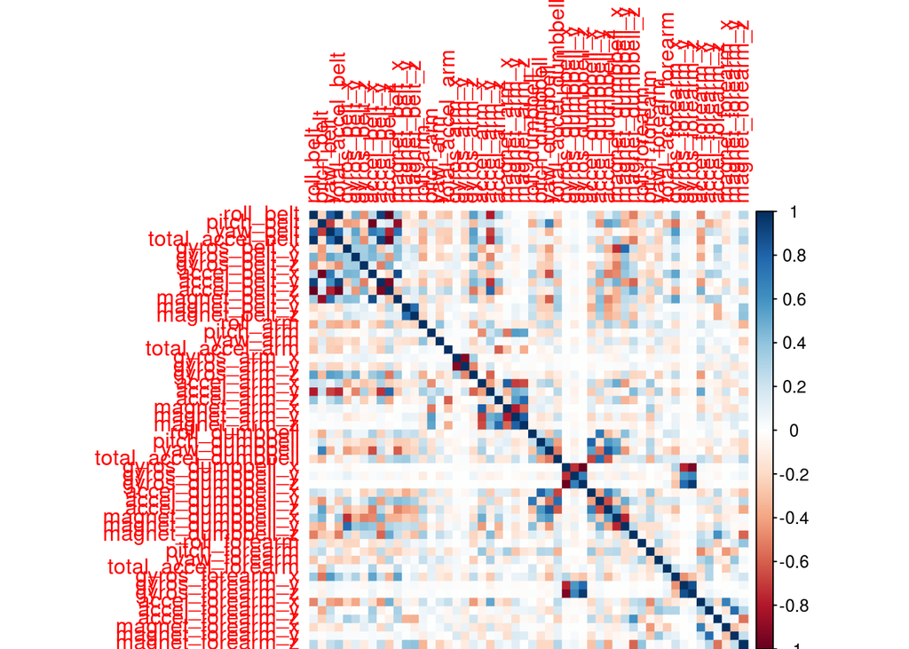

```r
corrplot(cor(train.final[,-53]),method="color")
```

There appear to be some clusters with highly correllated variables. Some of them seem to be from similar sensors, i.e. dumbell, forearm etc. Going to use principal components analysis to reduce set of variable to lower number of less correllated variables in train and test set.

```r
pca_train<-preProcess(train.final[,-53], method="pca")
train.transformed<-predict(pca_train,newdata=train.final[,-53])
test.trainsformed<-predict(pca_train,newdata=test.final[,-53])
```

#### Model

Since the outcome variable is a 5-level factor, we will use a **Random Forest** prediction model.

```r
set.seed(33222)
rand.forest<-train(y=train.final$classe,x=train.transformed,method="rf",ntree=50,tuneLength=1)
rand.forest
```

```
## Random Forest
##
## 13737 samples
##    25 predictor
##     5 classes: 'A', 'B', 'C', 'D', 'E'
##
## No pre-processing
## Resampling: Bootstrapped (25 reps)
## Summary of sample sizes: 13737, 13737, 13737, 13737, 13737, 13737, ...
## Resampling results:
##
##   Accuracy   Kappa
##   0.9530124  0.9405575
##
## Tuning parameter 'mtry' was held constant at a value of 8
```

#### Prediction

Using our rf-model on the test.transformed set and looking at the confusion matrix.

```r
pred.rf<-predict(rand.forest,test.trainsformed)
confusionMatrix(test.final$classe,pred.rf)
```

```
## Confusion Matrix and Statistics
##
##           Reference
## Prediction    A    B    C    D    E
##          A 1656    9    2    7    0
##          B   26 1094   18    0    1
##          C    2   16  994   13    1
##          D    1    2   39  919    3
##          E    0   11    6    6 1059
##
## Overall Statistics
##
##                Accuracy : 0.9723
##                  95% CI : (0.9678, 0.9763)
##     No Information Rate : 0.2863
##     P-Value [Acc > NIR] : < 2.2e-16
##
##                   Kappa : 0.965
##  Mcnemar's Test P-Value : NA
##
## Statistics by Class:
##
##                      Class: A Class: B Class: C Class: D Class: E
## Sensitivity            0.9828   0.9664   0.9386   0.9725   0.9953
## Specificity            0.9957   0.9905   0.9934   0.9909   0.9952
## Pos Pred Value         0.9892   0.9605   0.9688   0.9533   0.9787
## Neg Pred Value         0.9931   0.9920   0.9866   0.9947   0.9990
## Prevalence             0.2863   0.1924   0.1799   0.1606   0.1808
## Detection Rate         0.2814   0.1859   0.1689   0.1562   0.1799
## Detection Prevalence   0.2845   0.1935   0.1743   0.1638   0.1839
## Balanced Accuracy      0.9893   0.9785   0.9660   0.9817   0.9953
```

The model accuracy is 97.23% and the out of sample error is therefor 2.77%.

#### Quiz Prediction

First, performing the same pre-processing on the quiz set as on the train/test sets.

```r
quiz.reduced<-quiz[,-c(1,2,3,4,5,6,7)]
quiz.final<-quiz.reduced[,missingpcts<.8]
quiz.transformed<-predict(pca_train,newdata=quiz.final)
```

Now, creating the predictions.

```r
pred.quiz<-predict(rand.forest,quiz.transformed)
pred.quiz
```

```
##  [1] B A B A A E D B A A B C B A E E A B B B
## Levels: A B C D E
```